# childes_weird

## Based on “Average number of siblings” annotation column

### How many siblings in average?

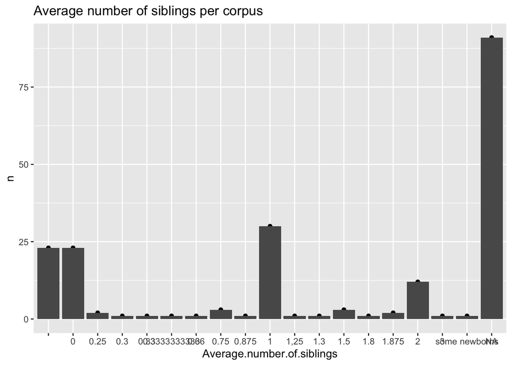

```r
bySiblnum<-annotations %>%
    group_by(Average.number.of.siblings) %>%
      count()

ggplot(bySiblnum, mapping = aes(x=Average.number.of.siblings, y=n)) +
  geom_point() +
    ggtitle("Average number of siblings per corpus") +
      geom_col()
```

```r
#ggplot(bySiblnum[!is.na(bySiblnum$Average.number.of.siblings),], mapping = aes(x=Average.number.of.siblings, y=n))

annotations$Average.number.of.siblings <- as.numeric(as.character(annotations$Average.number.of.siblings))
head(bySiblnum)
```

```
## # A tibble: 6 x 2
## # Groups:   Average.number.of.siblings [6]
##   Average.number.of.siblings     n
##   <chr>                      <int>
## 1 ""                            23
## 2 "0"                           23
## 3 "0.25"                         2
## 4 "0.3"                          1
## 5 "0.33"                         1
## 6 "0.3333333333"                 1
```

The mean number of siblings has been left NA for 91 out of 199 corpora. In the remaining corpora, the mean number of siblings per corpus is 0.8867269 with min 0 and max 3.

## Based on “Average number of older siblings” annotation column

### How many older siblings in average?

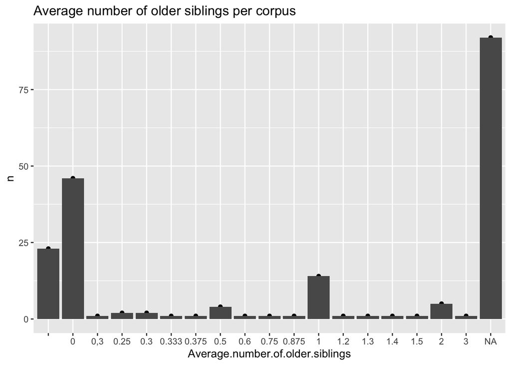

```r
byoldSiblnum<-annotations %>%
    group_by(Average.number.of.older.siblings) %>%
      count()

ggplot(byoldSiblnum, mapping = aes(x=Average.number.of.older.siblings, y=n)) +
  geom_point() +
    ggtitle("Average number of older siblings per corpus") +
      geom_col()
```

```r
annotations$Average.number.of.older.siblings <- as.numeric(as.character(annotations$Average.number.of.older.siblings))

head(byoldSiblnum)
```

```
## # A tibble: 6 x 2
## # Groups:   Average.number.of.older.siblings [6]
##   Average.number.of.older.siblings     n
##   <chr>                            <int>
## 1 ""                                  23
## 2 "0"                                 46
## 3 "0,3"                                1
## 4 "0.25"                               2
## 5 "0.3"                                2
## 6 "0.333"                              1
```

The mean number of older siblings has been left NA for 92 out of 199 corpora. In the remaining corpora, the mean number of older siblings per corpus is 0.4630482 with min NA and max 3.

# Sessions

## Based on “Mean sessions per child” annotation column

### How many sessions per language?

```r
bySess <- annotations[!is.na(annotations$mean_session_child), ]

bySess$mean_session_child <- sub(",",".",bySess$mean_session_child)
bySess$mean_session_child <- as.numeric(bySess$mean_session_child)

bySess<- bySess %>%
  mutate(sessions = as.numeric(number_participants) * mean_session_child) %>%
    group_by(language, bilingualism_corpus) %>%
      summarise(numses = sum(as.numeric(sessions)))


head(bySess)
```

```
## # A tibble: 6 x 3
## # Groups:   language [6]
##   language                                             bilingualism_corp… numses
##   <chr>                                                <chr>               <dbl>
## 1 Afrikaan                                             <NA>                   64
## 2 American English (Middle Atlantic mother, Texas fat… monolinguals           NA
## 3 Arabic                                               monolinguals           10
## 4 Basque                                               monolinguals          141
## 5 Brazilian Portuguese                                 monolinguals          340
## 6 British English                                      monolinguals          105
```

```r
#ggplot(bySess, mapping = aes(y = reorder(language, numses), numses)) +
#  geom_point() +
#  ggtitle("Number of sessions per language") +
#  geom_col()+
#  facet_wrap(~bilingualism_corpus, scale="free")
```

# Location

## Based on “Neighbour.village.city.province.state.country” annotation column

### For now only based on continents and countries. Lots of handcoding.

```r
annotations$continent <-NA

annotations$continent[grep("England|Sweden|Spain|Madrid, Spain ; Tenerife, Canary Islands|Madrid, Spain|Navarra, Spain|Estonia|Tartu, Estonia ; Rapla, Estonia|Budapest, Hungary|West Coast, Ireland|Arfon area Gwynedd, North Wales|Netherlands|Belfast, Northern Ireland|Nottingham/Manchester, England|Sweden ; Portugal|Czech Republic|Bucharest, Romania|Postdam, Germany|Stuttgart, Germany|France|Alt penedes, region of catalonia|spain|Naples|Spain, Hungary, Lloret de mar|Spain, Salamanca|England, Brighton|France (Normandy, Marseille, + places visited)|Portugal|italy|Barcelona|Switzerland|Stockholm, Sweden|Iceland|Poznań, Poland|Romania|Antwerp, Belgium|Ireland|Hungary|Athens, Greece|Southern Estonia|Tartu, Estonia|A Coruña, Santiago de Compostela ; Lugo ; Pontevedra, A Estrada ; SPAIN|Moscow, Russia|Spain, Salamanca|Wales", annotations$Neighbour.village.city.province.state.country)]  <- "Europe"

annotations$continent[grep("Rio Cuarto, Cordoba, Argentina|Sao Paulo|Patzcuaro, Michoacan, iMexico|Jamaica", annotations$Neighbour.village.city.province.state.country)]  <- "Central and South America"

annotations$continent[grep("Iran|Israel|Bombay, India|China|Bangkok, Thailand|Tokyo area|Nagoya area|osaka area|Kuwait|Yahud, Israel|Nagoya center|Kusatsu City, Shiga Pref|Hong-Kong|Taiwan|Turkey", annotations$Neighbour.village.city.province.state.country)]  <- "Asia"

annotations$continent[grep("Michigan, USA|USA, Northern Virginia|Canada|California, USA|washington dc|United States|USA", annotations$Neighbour.village.city.province.state.country)]  <- "North America"

annotations$continent[grep("Alexandria, Egypt|Mokhotlong, Lesotho", annotations$Neighbour.village.city.province.state.country)]  <- "Africa"


annotations$country <-NA
annotations$country[grep("England|West Coast, Ireland|Arfon area Gwynedd, North Wales|Belfast, Northern Ireland|Nottingham/Manchester, England|England, Brighton|Ireland|Wales", annotations$Neighbour.village.city.province.state.country)]  <- "UK/Ireland"
annotations$country[grep("Sweden|Sweden ; Portugal|Stockholm, Sweden", annotations$Neighbour.village.city.province.state.country)]  <- "Sweden"
annotations$country[grep("Spain|Madrid, Spain ; Tenerife, Canary Islands|Madrid, Spain|Navarra, Spain|Alt penedes, region of catalonia|spain|Spain, Hungary, Lloret de mar|Spain, Salamanca|Barcelona|A Coruña, Santiago de Compostela ; Lugo ; Pontevedra, A Estrada ; SPAIN|Spain, Salamanca", annotations$Neighbour.village.city.province.state.country)]  <- "Spain"
annotations$country[grep("Estonia|Tartu, Estonia ; Rapla, Estonia|Southern Estonia|Tartu, Estonia", annotations$Neighbour.village.city.province.state.country)]  <- "Estonia"
annotations$country[grep("Budapest, Hungary|Hungary|Spain, Hungary, Lloret de mar", annotations$Neighbour.village.city.province.state.country)]  <- "Hungary"
annotations$country[grep("Sweden ; Portugal|Portugal", annotations$Neighbour.village.city.province.state.country)]  <- "Portugal"
annotations$country[grep("Czech Republic", annotations$Neighbour.village.city.province.state.country)]  <- "Czech Republic"
annotations$country[grep("Bucharest, Romania|Romania", annotations$Neighbour.village.city.province.state.country)]  <- "Romania"
annotations$country[grep("Postdam, Germany|Stuttgart, Germany", annotations$Neighbour.village.city.province.state.country)]  <- "Germany"
annotations$country[grep("France|France (Normandy, Marseille, + places visited)", annotations$Neighbour.village.city.province.state.country)]  <- "France"
annotations$country[grep("Naples|italy", annotations$Neighbour.village.city.province.state.country)]  <- "Italy"
annotations$country[grep("Switzerland", annotations$Neighbour.village.city.province.state.country)]  <- "Switzerland"
annotations$country[grep("Iceland", annotations$Neighbour.village.city.province.state.country)]  <- "Iceland"
annotations$country[grep("Poznań, Poland", annotations$Neighbour.village.city.province.state.country)]  <- "Poland"
annotations$country[grep("Antwerp, Belgium", annotations$Neighbour.village.city.province.state.country)]  <- "Belgium"
annotations$country[grep("Athens, Greece", annotations$Neighbour.village.city.province.state.country)]  <- "Greece"
annotations$country[grep("Moscow, Russia", annotations$Neighbour.village.city.province.state.country)]  <- "Russia"
annotations$country[grep("Rio Cuarto, Cordoba, Argentina", annotations$Neighbour.village.city.province.state.country)]  <- "Argentina"
annotations$country[grep("Sao Paulo", annotations$Neighbour.village.city.province.state.country)]  <- "Brazil"
annotations$country[grep("Patzcuaro, Michoacan, iMexico", annotations$Neighbour.village.city.province.state.country)]  <- "Mexico"
annotations$country[grep("Jamaica", annotations$Neighbour.village.city.province.state.country)]  <- "Jamaica"
annotations$country[grep("Iran", annotations$Neighbour.village.city.province.state.country)]  <- "Iran"
annotations$country[grep("Israel|Yahud, Israel", annotations$Neighbour.village.city.province.state.country)]  <- "Israel"
annotations$country[grep("Bombay, India", annotations$Neighbour.village.city.province.state.country)]  <- "India"
annotations$country[grep("China", annotations$Neighbour.village.city.province.state.country)]  <- "China"
annotations$country[grep("Bangkok, Thailand", annotations$Neighbour.village.city.province.state.country)]  <- "Thailand"
annotations$country[grep("Tokyo area|Nagoya area|osaka area|Nagoya center|Kusatsu City, Shiga Pref", annotations$Neighbour.village.city.province.state.country)]  <- "Japan"
annotations$country[grep("Kuwait", annotations$Neighbour.village.city.province.state.country)]  <- "Kuwait"
annotations$country[grep("Hong-Kong", annotations$Neighbour.village.city.province.state.country)]  <- "Hong-Kong"
annotations$country[grep("Taiwan", annotations$Neighbour.village.city.province.state.country)]  <- "Taiwan"
annotations$country[grep("Turkey", annotations$Neighbour.village.city.province.state.country)]  <- "Turkey"
annotations$country[grep("Michigan, USA|USA, Northern Virginia|California, USA|washington dc|United States|USA", annotations$Neighbour.village.city.province.state.country)]  <- "USA"
annotations$country[grep("Canada", annotations$Neighbour.village.city.province.state.country)]  <- "Canada"
annotations$country[grep("Alexandria, Egypt", annotations$Neighbour.village.city.province.state.country)]  <- "Egypt"
annotations$country[grep("Mokhotlong, Lesotho", annotations$Neighbour.village.city.province.state.country)]  <- "Lesotho"
```